# VAR_MSCI

Masaki Mori

2021/7/26

# 準備

## 使用データ

MSCIが提供している株式指数を用いた.

- https://www.msci.com/

## データの読込

```r
library(readxl) # パッケージの読込
# xlsファイルを読込, 変数に代入
JP <- read_excel("raw/JP.xls") # 日本
SP <- read_excel("raw/SP.xls") # シンガポール
US <- read_excel("raw/USA.xls") # アメリカ
```

## データの確認

データを時系列に変換する.

```r
library(quantmod) # パッケージの読込
library(lubridate) # パッケージの読み込み
# 日付型の変換・xts型に変換
preprocess <- function(df) {
  df <- as.data.frame(df)
  df$month <- sapply(df[,1], function(x) {
    x <- gsub(",", "", x)
    x <- gsub(" ", "/", x)
    x <- gsub("Apr", "4", x)
    x <- gsub("May", "5", x)
    x <- gsub("Jun", "6", x)
    x <- gsub("Jul", "7", x)
    x <- gsub("Aug", "8", x)
    x <- gsub("Sep", "9", x)
    x <- gsub("Oct", "10", x)
    x <- gsub("Nov", "11", x)
    x <- gsub("Dec", "12", x)
    x <- gsub("Jan", "1", x)
    x <- gsub("Feb", "2", x)
    x <- gsub("Mar", "3", x)
  })
  df$Date <- mdy(df$month)
  df <- df[,-3]
  df <- as.xts(read.zoo(df))
}
```

```r
JP <- preprocess(JP) #JPの日付型を変換
SP <- preprocess(SP) #SPの日付型を変換
US <- preprocess(US) #USの日付型を変換
```

日付情報が同じであるか確認する.

```r
sum(index(JP) != index(SP)) #JP,SPの日付が異なる数
```

```
## [1] 0
```

```r
sum(index(JP) != index(US)) #JP,USの日付が異なる数
```

```
## [1] 0
```

欠損値の有無を確認する.

```r
# データ結合
MSCI <- cbind(JP,SP,US) #外生性の高い順に(=時差が短い順)
MSCI <- MSCI['2016-01-01::2019-12-31']
sum(is.na(MSCI)) #欠損地の数
```

```
## [1] 0
```

データ数は次である.

```r
length(MSCI) # データ数
```

```
## [1] 3129
```

データの中身を確認する.

```r
head(MSCI) # 最初の数個を表示
```

```
##                  JP       SP       US
## 2016-01-01 2808.288 3253.595 1949.703
## 2016-01-04 2763.005 3174.291 1919.953
## 2016-01-05 2755.333 3172.500 1923.621
## 2016-01-06 2736.138 3117.903 1897.552
## 2016-01-07 2688.748 3040.152 1852.166
## 2016-01-08 2679.853 3053.890 1831.877
```

```r
tail(MSCI) # 最後の数個を表示
```

```
##                  JP       SP       US
## 2019-12-24 3430.825 3925.036 3069.660
## 2019-12-25 3419.875 3925.036 3069.660
## 2019-12-26 3428.756 3929.473 3085.408
## 2019-12-27 3431.012 3938.383 3085.407
## 2019-12-30 3427.403 3941.420 3067.305
## 2019-12-31 3437.179 3958.788 3076.489
```

# データの概要

## 株式指数

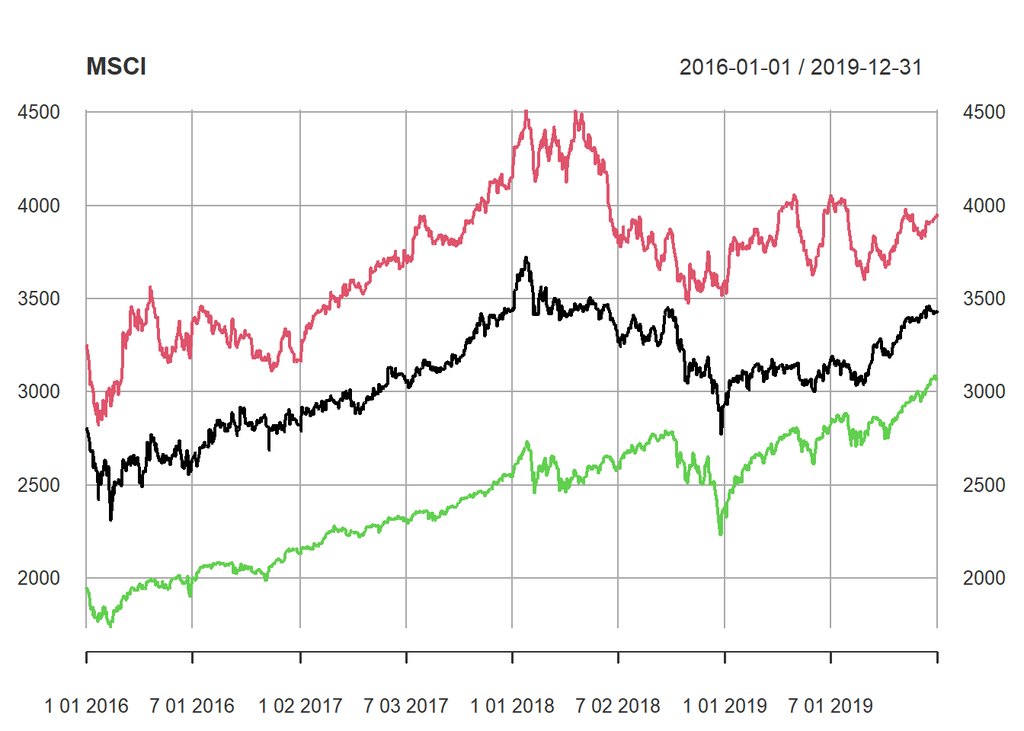

```r
plot(MSCI) # 時系列プロット
```

```r
summary(coredata(MSCI)) # 株式指数の記述統計量
```

```
##        JP             SP             US
##  Min.   :2311   Min.   :2823   Min.   :1734
##  1st Qu.:2884   1st Qu.:3428   1st Qu.:2157
##  Median :3105   Median :3742   Median :2480
##  Mean   :3085   Mean   :3702   Mean   :2428
##  3rd Qu.:3317   3rd Qu.:3917   3rd Qu.:2684
##  Max.   :3726   Max.   :4511   Max.   :3085
```

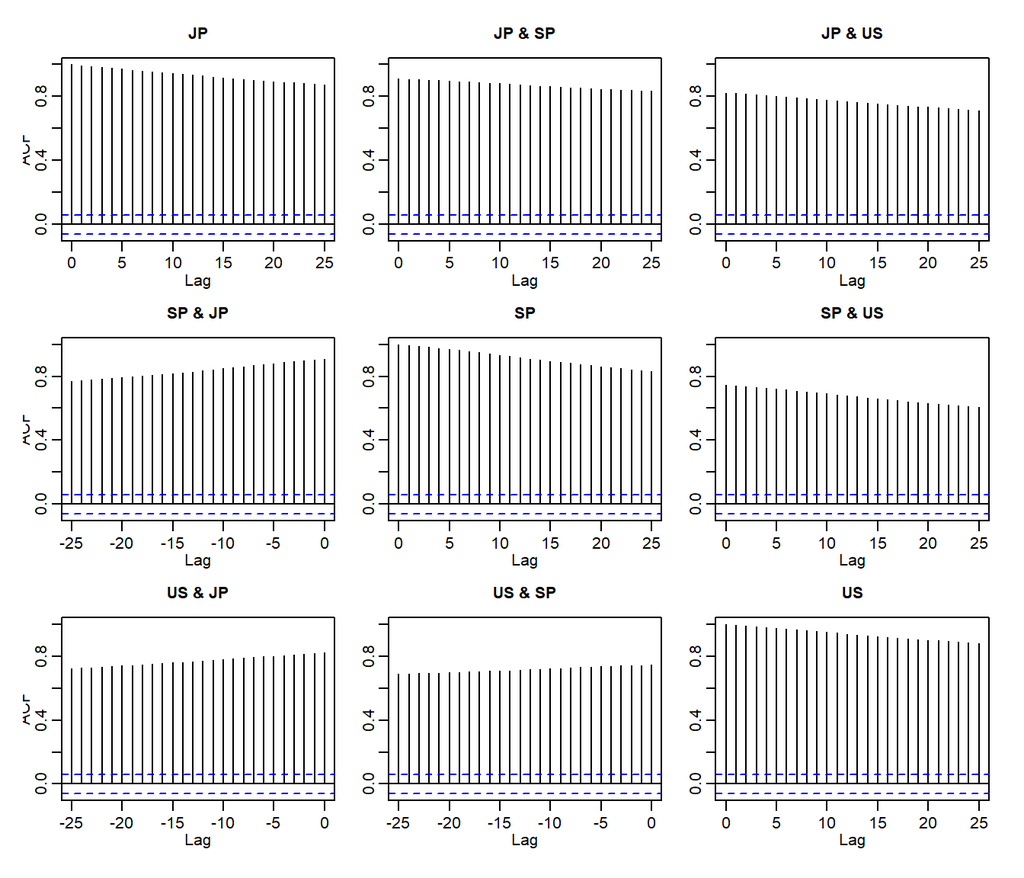

```r
acf(coredata(MSCI)) # 株式指数の自己相関
```

対角線を見ると、定常でないことが読み取れる

## 対数収益率

対数収益率 (%) に変換する.

```r
JP.r <- dailyReturn(MSCI$JP, type = 'log') * 100 # 日本
SP.r <- dailyReturn(MSCI$SP, type = 'log') * 100 # シンガポール
US.r <- dailyReturn(MSCI$US, type = 'log') * 100 # 香港
MSCI.r <- cbind(JP.r, SP.r, US.r) # データを結合
names(MSCI.r) <- names(MSCI) # 名を変更
```

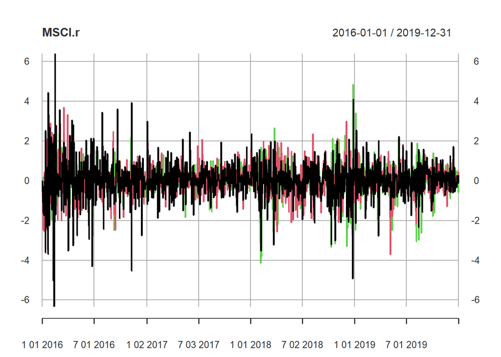

```r
plot(MSCI.r) # 時系列プロット
```

```r
summary(coredata(MSCI.r)) # 株式指数の対数収益率の記述統計量
```

```
##        JP                 SP                 US
##  Min.   :-6.33053   Min.   :-3.70727   Min.   :-4.13657
##  1st Qu.:-0.49837   1st Qu.:-0.46064   1st Qu.:-0.22728
##  Median : 0.04965   Median : 0.01637   Median : 0.03245
##  Mean   : 0.01937   Mean   : 0.01881   Mean   : 0.04373
##  3rd Qu.: 0.53520   3rd Qu.: 0.49827   3rd Qu.: 0.43489
##  Max.   : 6.39091   Max.   : 3.68542   Max.   : 4.85214
```

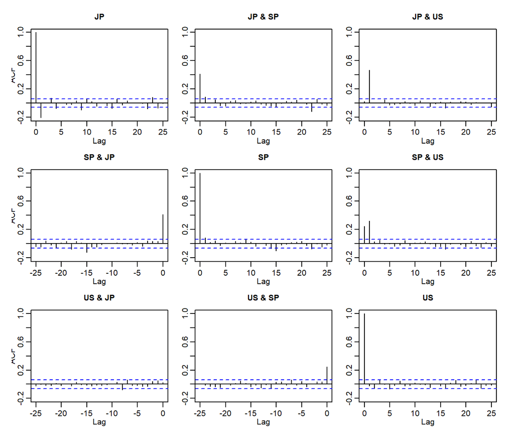

```r
acf(coredata(MSCI.r)) # 株式指数の対数収益率の自己相関
```

# 推定

パッケージ「vars」を用いて分析を行う.

```r
library(vars) # パッケージの読込
```

## 推定

情報量基準を求める.

```r
(IC <- VARselect(MSCI.r)) # 情報量基準
```

```
## $selection
## AIC(n)  HQ(n)  SC(n) FPE(n)
##      2      2      1      2
##
## $criteria
##                 1         2          3          4          5          6
## AIC(n) -1.3147261 -1.348013 -1.3416719 -1.3354700 -1.3319283 -1.3198698
## HQ(n)  -1.2929488 -1.309903 -1.2872285 -1.2646935 -1.2448188 -1.2164274
## SC(n)  -1.2573373 -1.247583 -1.1981998 -1.1489562 -1.1023729 -1.0472729
## FPE(n)  0.2685479  0.259756  0.2614087  0.2630356  0.2639697  0.2671734
##                 7          8          9         10
## AIC(n) -1.3169477 -1.3111449 -1.3122935 -1.2969036
## HQ(n)  -1.1971722 -1.1750365 -1.1598520 -1.1281291
## SC(n)  -1.0013091 -0.9524647 -0.9105717 -0.8521401
## FPE(n)  0.2679571  0.2695189  0.2692127  0.2733917
```

ここでSC(n)はBIC基準である。 AICではVAR(2), BICではVAR(1)であるから, 両方用いてパラメータ推定を行う.

```r
m.a <- VAR(MSCI.r, lag.max = 10, ic = "AIC") # AICによるモデルの推定
m.b <- VAR(MSCI.r, lag.max = 10, ic = "SC") # BICによるモデルの推定
```

推定結果を表示する. VAR(2)の結果は量が多いので, VAR(1)の結果のみ表示する.

```r
summary(m.b) # 推定結果を表示
```

```
##
## VAR Estimation Results:
## =========================
## Endogenous variables: JP, SP, US
## Deterministic variables: const
## Sample size: 1042
## Log Likelihood: -3765.191
## Roots of the characteristic polynomial:
## 0.3075 0.1232 0.1035
## Call:
## VAR(y = MSCI.r, lag.max = 10, ic = "SC")
##
##
## Estimation results for equation JP:
## ===================================
## JP = JP.l1 + SP.l1 + US.l1 + const
##
##        Estimate Std. Error t value Pr(>|t|)
## JP.l1 -0.247772   0.029240  -8.474  < 2e-16 ***
## SP.l1  0.094856   0.036041   2.632  0.00862 **
## US.l1  0.589178   0.035488  16.602  < 2e-16 ***
## const -0.003236   0.027487  -0.118  0.90630
## ---
## Signif. codes:  0 '***' 0.001 '**' 0.01 '*' 0.05 '.' 0.1 ' ' 1
##
##
## Residual standard error: 0.8858 on 1038 degrees of freedom
## Multiple R-Squared: 0.2711,  Adjusted R-squared: 0.269
## F-statistic: 128.7 on 3 and 1038 DF,  p-value: < 2.2e-16
##
##
## Estimation results for equation SP:
## ===================================
## SP = JP.l1 + SP.l1 + US.l1 + const
##
##        Estimate Std. Error t value Pr(>|t|)
## JP.l1  0.024686   0.027093   0.911    0.362
## SP.l1 -0.007465   0.033394  -0.224    0.823
## US.l1  0.351512   0.032882  10.690   <2e-16 ***
## const  0.003207   0.025468   0.126    0.900
```

[output cut: 24 more lines]

```
## F-statistic: 1.293 on 3 and 1038 DF,  p-value: 0.2755
##
##
##
## Covariance matrix of residuals:
##         JP     SP      US
## JP 0.78470 0.2425 0.03643
## SP 0.24255 0.6737 0.17464
## US 0.03643 0.1746 0.64091
##
## Correlation matrix of residuals:
##         JP     SP      US
## JP 1.00000 0.3336 0.05137
## SP 0.33359 1.0000 0.26577
## US 0.05137 0.2658 1.00000
```

今回はインパルス応答関数を調べる為、予測がメイン。よって、係数の優意性から、係数を削除することはしない。

## モデル診断

残差の自己相関を調べ, モデルが適切かどうかを診断する.

まず, コレログラムをプロットする.

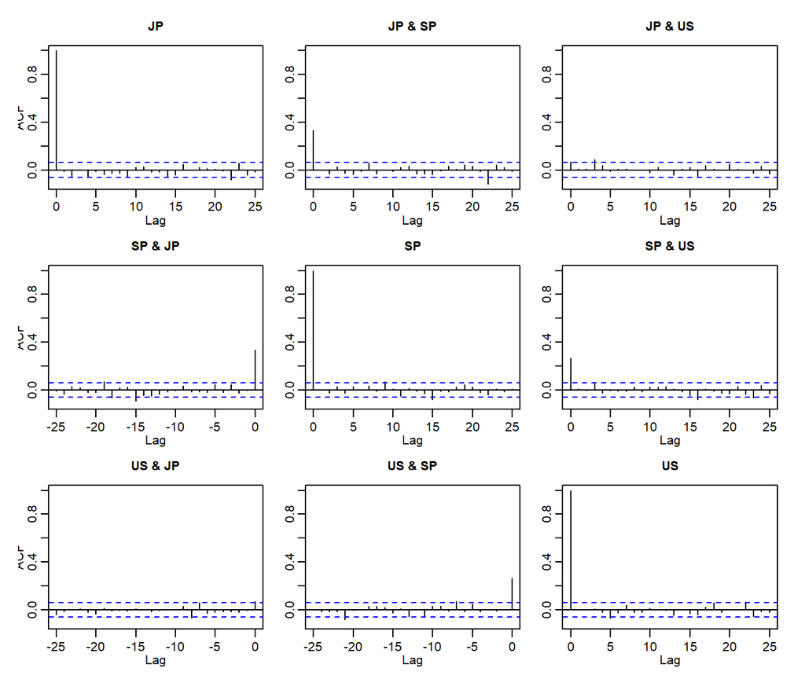

```r
acf(residuals(m.a)) # 残差の自己相関
```

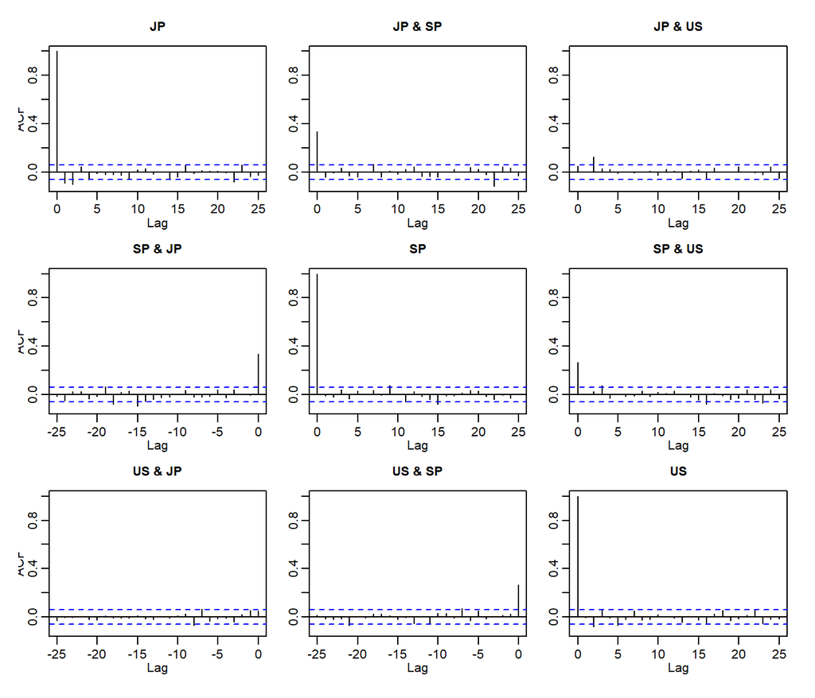

```r
acf(residuals(m.b)) # 残差の自己相関
```

次に, かばん検定を行う.

```r
serial.test(m.a, lags.pt = 10, type = "PT.adjusted") # ラグ10
```

```
##
##  Portmanteau Test (adjusted)
##
## data:  Residuals of VAR object m.a
## Chi-squared = 85.937, df = 72, p-value = 0.1253
```

```r
serial.test(m.a, lags.pt = 15, type = "PT.adjusted") # ラグ15
```

```
##
##  Portmanteau Test (adjusted)
##
## data:  Residuals of VAR object m.a
## Chi-squared = 132.68, df = 117, p-value = 0.1525
```

```r
serial.test(m.a, lags.pt = 20, type = "PT.adjusted") # ラグ20
```

```
##
##  Portmanteau Test (adjusted)
##
## data:  Residuals of VAR object m.a
## Chi-squared = 185.55, df = 162, p-value = 0.09912
```

全てにおいてp値が0.05より大きいので, 有意水準5%で帰無仮説を棄却できない. つまり, 残差に自己相関があると判断できないので, 適切である．

```r
serial.test(m.b, lags.pt = 10, type = "PT.adjusted") # ラグ10
```

```
##
##  Portmanteau Test (adjusted)
##
## data:  Residuals of VAR object m.b
## Chi-squared = 137.61, df = 81, p-value = 8.886e-05
```

```r
serial.test(m.b, lags.pt = 15, type = "PT.adjusted") # ラグ15
```

```
##
##  Portmanteau Test (adjusted)
##
## data:  Residuals of VAR object m.b
## Chi-squared = 185.65, df = 126, p-value = 0.0004354
```

```r
serial.test(m.b, lags.pt = 20, type = "PT.adjusted") # ラグ20
```

```
##
##  Portmanteau Test (adjusted)
##
## data:  Residuals of VAR object m.b
## Chi-squared = 239.37, df = 171, p-value = 0.0004349
```

全てにおいてp値が0.05より小さいので, 有意水準5%で帰無仮説を棄却する．つまり, 残差に自己相関があると判断できるので, 適切でない．

# 分析

モデル診断の結果より, AICによるモデルの推定結果を用いて分析を行う.

## グレンジャー因果性

グレンジャー因果性の検定を行う.

```r
causality(m.a, cause = "JP") # JP → SP, US
```

```
## $Granger
##
##  Granger causality H0: JP do not Granger-cause SP US
##
## data:  VAR object m.a
## F-Test = 1.8404, df1 = 4, df2 = 3102, p-value = 0.1183
##
##
## $Instant
##
##  H0: No instantaneous causality between: JP and SP US
##
## data:  VAR object m.a
## Chi-squared = 105.22, df = 2, p-value < 2.2e-16
```

これは, 1つの変数の他の全ての変数に対する検定であり, 他の1つの変数に対する検定ではない. 関数「causality」では, 他の1つの変数に対する検定を行うには2変量VARモデルを用いなければならない.

### 日本とシンガポール

```r
JPSP <- cbind(MSCI.r$JP, MSCI.r$SP) # 日本とイギリスのデータ
m1.a <- VAR(JPSP, lag.max =10, ic = "AIC") # AICによるモデルの推定
m1.a$p # VARの次数
```

```
## AIC(n)
##      2
```

```r
serial.test(m1.a, lags.pt = 15, type = "PT.adjusted") # ラグ15のかばん検定
```

```
##
##  Portmanteau Test (adjusted)
##
## data:  Residuals of VAR object m1.a
## Chi-squared = 69.089, df = 52, p-value = 0.05651
```

```r
causality(m1.a, cause = "JP") # JP → SP
```

```
## $Granger
##
##  Granger causality H0: JP do not Granger-cause SP
##
## data:  VAR object m1.a
## F-Test = 0.52985, df1 = 2, df2 = 2072, p-value = 0.5888
##
##
## $Instant
##
##  H0: No instantaneous causality between: JP and SP
##
## data:  VAR object m1.a
## Chi-squared = 160.99, df = 1, p-value < 2.2e-16
```

p値が0.05より大きいので, 有意水準5%で帰無仮説を棄却できない．つまり, 日本からシンガポールへのグレンジャー因果性は存在すると判断できない．

```r
causality(m1.a, cause = "SP") # SP → JP
```

```
## $Granger
##
##  Granger causality H0: SP do not Granger-cause JP
##
## data:  VAR object m1.a
## F-Test = 23.334, df1 = 2, df2 = 2072, p-value = 9.524e-11
##
##
## $Instant
##
##  H0: No instantaneous causality between: SP and JP
##
## data:  VAR object m1.a
## Chi-squared = 160.99, df = 1, p-value < 2.2e-16
```

p値が0.05より小さいので, 有意水準5%で帰無仮説を棄却する．つまり, シンガポールから日本へのグレンジャー因果性は存在すると判断できる．

### 日本とアメリカ

```r
JPUS <- cbind(MSCI.r$JP, MSCI.r$US) # 日本とアメリカのデータ
m2.a <- VAR(JPUS, lag.max =10, ic = "AIC") # AICによるモデルの推定
m2.a$p # VARの次数
```

```
## AIC(n)
##      3
```

```r
serial.test(m2.a, lags.pt = 15, type = "PT.adjusted") # ラグ15のかばん検定
```

```
##
##  Portmanteau Test (adjusted)
##
## data:  Residuals of VAR object m2.a
## Chi-squared = 49.789, df = 48, p-value = 0.402
```

```r
causality(m2.a, cause = "JP") # JP → US
```

```
## $Granger
##
##  Granger causality H0: JP do not Granger-cause US
##
## data:  VAR object m2.a
## F-Test = 3.2377, df1 = 3, df2 = 2066, p-value = 0.02137
##
##
## $Instant
##
##  H0: No instantaneous causality between: JP and US
##
## data:  VAR object m2.a
## Chi-squared = 5.0791, df = 1, p-value = 0.02422
```

```r
causality(m2.a, cause = "US") # US → JP
```

```
## $Granger
##
##  Granger causality H0: US do not Granger-cause JP
##
## data:  VAR object m2.a
## F-Test = 123.59, df1 = 3, df2 = 2066, p-value < 2.2e-16
##
##
## $Instant
##
##  H0: No instantaneous causality between: US and JP
##
## data:  VAR object m2.a
## Chi-squared = 5.0791, df = 1, p-value = 0.02422
```

p値が0.05より小さいので, 有意水準5%で帰無仮説を棄却する．つまり, アメリカから日本へのグレンジャー因果性は存在すると判断できる．

### シンガポールとアメリカ

```r
SPUS <- cbind(MSCI.r$SP, MSCI.r$US) # イギリスとアメリカのデータ
m3.a <- VAR(SPUS, lag.max =10, ic = "AIC") # AICによるモデルの推定
m3.a$p # VARの次数
```

```
## AIC(n)
##      2
```

```r
serial.test(m3.a, lags.pt = 15, type = "PT.adjusted") # ラグ15のかばん検定
```

```
##
##  Portmanteau Test (adjusted)
##
## data:  Residuals of VAR object m3.a
## Chi-squared = 56.001, df = 52, p-value = 0.3272
```

```r
causality(m3.a, cause = "SP") # SP → US
```

```
## $Granger
##
##  Granger causality H0: SP do not Granger-cause US
##
## data:  VAR object m3.a
## F-Test = 3.7943, df1 = 2, df2 = 2072, p-value = 0.02265
##
##
## $Instant
##
##  H0: No instantaneous causality between: SP and US
##
## data:  VAR object m3.a
## Chi-squared = 69.06, df = 1, p-value < 2.2e-16
```

p値が0.05より小さいので, 有意水準5%で帰無仮説を棄却する．つまり, シンガポールからアメリカへのグレンジャー因果性は存在すると判断できる

```r
causality(m3.a, cause = "US") # US → SP
```

```
## $Granger
##
##  Granger causality H0: US do not Granger-cause SP
##
## data:  VAR object m3.a
## F-Test = 57.788, df1 = 2, df2 = 2072, p-value < 2.2e-16
##
##
## $Instant
##
##  H0: No instantaneous causality between: US and SP
##
## data:  VAR object m3.a
## Chi-squared = 69.06, df = 1, p-value < 2.2e-16
```

p値が0.05より小さいので, 有意水準5%で帰無仮説を棄却する．つまり, アメリカからシンガポールへのグレンジャー因果性は存在すると判断できる

## インパルス応答関数

IRFを計算しプロットする.

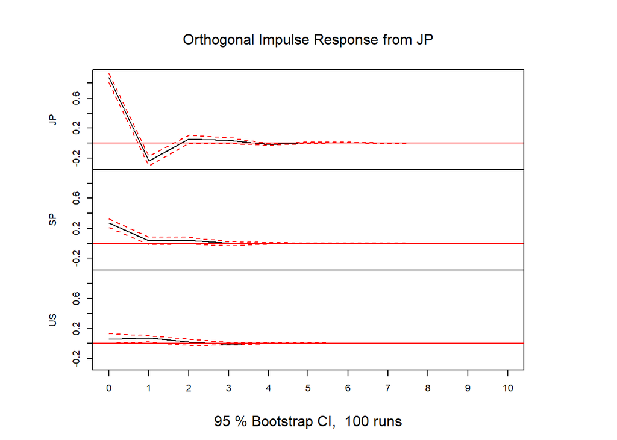

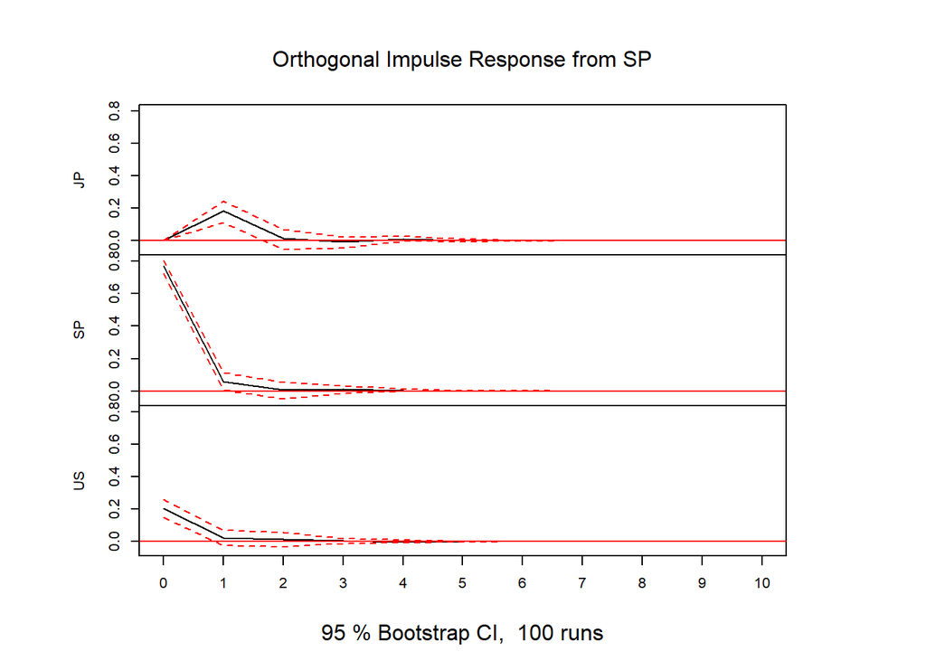

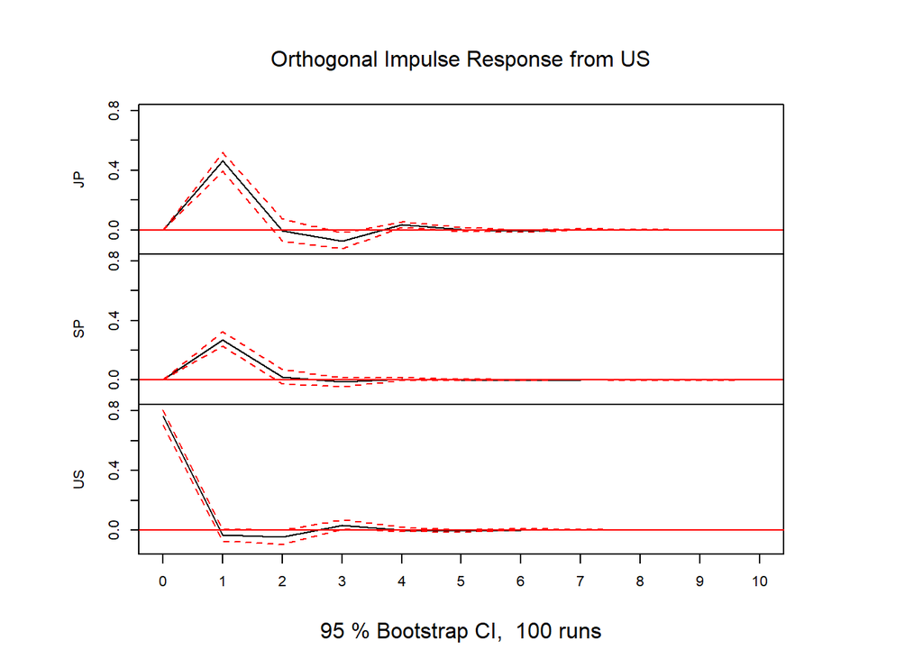

```r
m.a.irf <- irf(m.a) # IRFを計算
plot(m.a.irf) # プロット
```

## 分散分解

RVCを計算しプロットする.

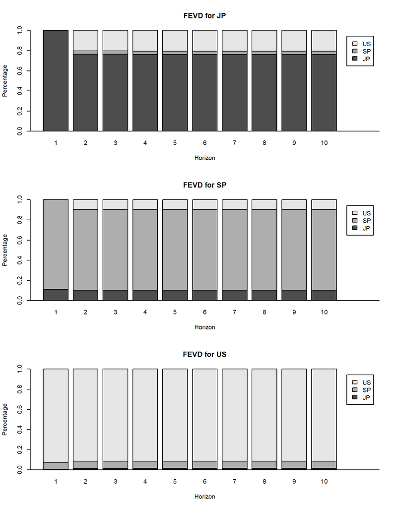

```r
m.a.rvc <- fevd(m.a) # RVCを計算, Forecast Error Variance Decomposition
plot(m.a.rvc) # プロット
```